# Food Deserts - Supervised Learning Analysis

20-06-2022

# **Assignment 2: Food Desets - Supervised Analysis**

Group members: Christian Marcelo Chafla Bastidas r0874332, Anja Derić r0873512, Theodore Gautier r0814273, Peter Day r0866276

# Overview

1. Research question
2. Research design
3. Analysis
4. Results
5. Conclusion
6. Elevator pitch

# 1. Research question

Is number of grocery stores per square mile related to obesity when controlling for a number of other variables?

This is relevant because, it shows heterogeneous distribution of grocery stores can lead to a number of health problems and disproportionately effects poor, less-educated and black people.

# 2. Design

# 3. Analysis

Step 1: Data sources:

Grocery store data: [National Neighborhood Data Archive (NaNDA): Grocery Stores by ZIP Code Tabulation Area, United States, 2003-2017](https://www.openicpsr.org/openicpsr/project/123042/version/V1/view)

Demographic data: [US Census: American Community Survey (ACS)](https://www.census.gov/programs-surveys/acs/)

Health data: [US CDC: PLACES: Local Data for Better Health, ZCTA Data 2021 release](https://chronicdata.cdc.gov/500-Cities-Places/PLACES-Local-Data-for-Better-Health-ZCTA-Data-2021/qnzd-25i4)

Our data come from the above three sources. All data are estimates for United States ZIP Code Tabulation Areas, which we used to join the various datasets. In the case of missing data we mostly removed the observations. With this much data we didn’t want to accidentally impute a value, say zip code, which makes no sense to impute. In addition we ended up with data for 28,000 ZCTAs, and thus were not lacking for data. The health data had estimates for 32 health conditions, which we narrowed down to five. The grocery store data had 32 variables which we narrowed down considerably, focusing on supermarkets/grocery stores and not on specialty food or warehouse club stores. Some renaming of variables was done to clarify variable meanings.

The rest of the data come from the American Community Survey from the US Census. Some of these files had up to 700 variables, including estimates as well as margin of error fields, which we did not use. These files came with metadata files which aided greatly in narrowing down the number of variables. As we had race data for each ZCTA we decided not to include educational data broken down by race. The education data cleaning included many renames to make the variable names as concise and meaningful as possible. We used mean household income for each ZCTA. Race estimates were in seven catagories, including alaskan native, asian, black and white.

```r
grocery <- read.csv('./grocery/grocery.csv')
health <- read.csv('./health/health.csv')
race <- read.csv('./race/race.csv')
income <- read.csv('./income/income_cleaned.csv')
edu <- read.csv('./education/edu.csv')
```

# Join, clean, variable selection part 1

```r
# data has all variables, dat will be used for analysis
data <- inner_join(grocery, health, by='zcta')
data <- inner_join(data, race, by='zcta')
data <- inner_join(data, income, by='zcta')
data <- inner_join(data, edu, by='zcta')
# found an na in grocery_per1k - imputed value with median
sum(is.na(data))
```

```
## [1] 1
```

```r
which(is.na(data), arr.ind=TRUE)
```

```
##        row col
## [1,] 23785   6
```

```r
data$grocery_per1k[is.na(data$grocery_per1k)] <- median(data$grocery_per1k, na.rm = T)
sum(is.na(data))
```

```
## [1] 0
```

```r
# remove zcta, year, Year and geolocation (lat&long) for supervised learning
dat <- data[-c(1,2,8,9)]
# initial linear regressions suggested that some of the age
# ranges are not linearly associated with obesity
dat <- dat[-c(21,22,23,24,25,26,27,28,29,30,31,32,33)]
# and mixed race seems to have problems... multicollinearity?
dat <- dat[-19]
# Removing population stats due to multicollinearity
dat <- dat[-c(1,6,12)]
```

# Some interesting zip codes

```r
summary(data$OBESITY)
```

```
##    Min. 1st Qu.  Median    Mean 3rd Qu.    Max.
##   12.90   31.30   35.00   34.35   37.80   56.30
```

```r
summary(data$grocery_persqmile)
```

```
##      Min.   1st Qu.    Median      Mean   3rd Qu.      Max.
##   0.00000   0.00000   0.02137   0.81348   0.17366 154.73620
```

```r
summary(data$grocery_count)
```

```
##    Min. 1st Qu.  Median    Mean 3rd Qu.    Max.
##   0.000   0.000   1.000   4.383   5.000 146.000
```

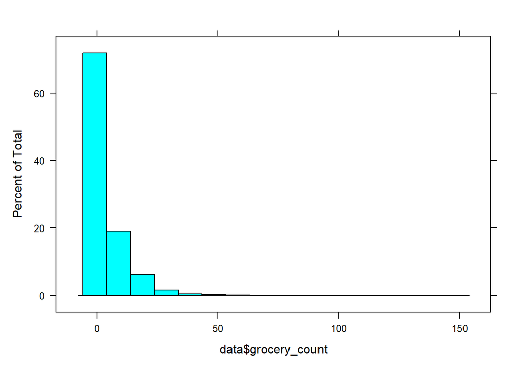

```r
histogram(data$grocery_count)
```

```r
# zcta = 10*** = NYC
# Lawrence, Massachusetts 01841
# Boston, Massachusetts 02128
# Hartford, Connecticut 06106
data %>% filter(grocery_count>50)
```

| zcta | year | population | aland10 | grocery_count | grocery_per1k | grocery_persqmile | Year | Geolocation | TotalPopulation | OBESITY | DEPRESSION | CANCER | CHOLSCREEN | CHD | tot_pop | white | black | alaskan_native | asian | pacific_islan | other | mixed_race | mean_income | X18.24_ltHS | X18.24_HSequiv | X18.24_assoc | X18.24_gtbach | gt25_lt9 | gt25_ltHS | … |
| --- | --- | --- | --- | --- | --- | --- | --- | --- | --- | --- | --- | --- | --- | --- | --- | --- | --- | --- | --- | --- | --- | --- | --- | --- | --- | --- | --- | --- | --- | --- |
| 1841 | 2017 | 48295 | 3.0882700 | 65 | 1.3458950 | 21.0473800 | 2019 | POINT (-71.1622865 42.71697501) | 47225 | 33.2 | 18.9 | 4.5 | 84.0 | 6.0 | 49437 | 23242 | 2586 | 278 | 492 | 0 | 18613 | 8452 | 57975 | 21.1 | 39.1 | 32.7 | 7.1 | 20.9 | 14.4 | … |
| 2128 | 2017 | 46655 | 4.8509580 | 51 | 1.0931300 | 10.5133900 | 2019 | POINT (-71.015624 42.36281022) | 40508 | 25.4 | 19.6 | 4.9 | 84.9 | 4.9 | 47804 | 27544 | 1513 | 246 | 2144 | 77 | 2749 | 27062 | 87285 | 19.7 | 23.3 | 35.9 | 21.1 | 17.0 | 8.3 | … |
| 6106 | 2017 | 38296 | 4.2263610 | 55 | 1.4361810 | 13.0135600 | 2019 | POINT (-72.69490357 41.74870984) | 39902 | 36.5 | 17.5 | 4.4 | 86.1 | 5.4 | 38012 | 14983 | 8295 | 206 | 1026 | 0 | 8104 | 10796 | 51958 | 15.3 | 25.8 | 55.3 | 3.7 | 17.8 | 15.1 | … |
| 10002 | 2017 | 77925 | 0.8784496 | 95 | 1.2191210 | 108.1451000 | 2019 | POINT (-73.98624471 40.71580125) | 81410 | 20.3 | 17.3 | 5.6 | 87.4 | 7.1 | 74363 | 23574 | 6645 | 713 | 31140 | 0 | 7944 | 8694 | 70204 | 9.8 | 17.5 | 43.4 | 29.3 | 19.0 | 14.8 | … |
| 10003 | 2017 | 55035 | 0.5764517 | 51 | 0.9266830 | 88.4722900 | 2019 | POINT (-73.98918087 40.73182933) | 56024 | 16.4 | 20.5 | 4.8 | 88.8 | 2.9 | 54671 | 39951 | 2759 | 112 | 8244 | 69 | 1329 | 4414 | 211756 | 0.7 | 27.9 | 53.8 | 17.6 | 2.9 | 1.5 | … |
| 10011 | 2017 | 50711 | 0.6618127 | 53 | 1.0451380 | 80.0830800 | 2019 | POINT (-74.00036133 40.74179596) | 50984 | 18.5 | 19.5 | 5.9 | 92.1 | 3.6 | 50228 | 39014 | 2303 | 26 | 4477 | 7 | 1704 | 5394 | 210553 | 5.4 | 17.6 | 39.1 | 38.0 | 1.9 | 1.9 | … |
| 10013 | 2017 | 29619 | 0.5502292 | 54 | 1.8231540 | 98.1409200 | 2019 | POINT (-74.00481595 40.72009702) | 27700 | 16.1 | 17.5 | 5.2 | 90.1 | 4.2 | 28657 | 17734 | 940 | 30 | 8115 | 0 | 568 | 2540 | 294915 | 6.7 | 11.7 | 46.5 | 35.1 | 10.2 | 6.2 | … |
| 10016 | 2017 | 51448 | 0.5321133 | 53 | 1.0301660 | 99.6028600 | 2019 | POINT (-73.97834243 40.74522079) | 54183 | 16.0 | 19.6 | 5.0 | 90.3 | 2.8 | 52912 | 36986 | 1764 | 83 | 9767 | 31 | 600 | 7362 | 181643 | 2.9 | 7.1 | 19.0 | 71.0 | 2.3 | 1.9 | … |
| 10025 | 2017 | 94382 | 0.7516378 | 53 | 0.5615478 | 70.5126900 | 2019 | POINT (-73.96662227 40.79860116) | 94600 | 20.7 | 19.5 | 6.5 | 91.4 | 4.8 | 92162 | 59085 | 9754 | 57 | 9188 | 9 | 7119 | 13900 | 176758 | 2.1 | 10.2 | 47.5 | 40.2 | 6.0 | 4.0 | … |
| 10029 | 2017 | 80866 | 0.8117273 | 91 | 1.1253180 | 112.1066000 | 2019 | POINT (-73.9439743 40.79176875) | 76003 | 28.1 | 20.0 | 5.2 | 87.7 | 6.2 | 74617 | 23188 | 23400 | 549 | 8142 | 125 | 16062 | 6302 | 71046 | 10.8 | 25.4 | 43.6 | 20.2 | 12.4 | 12.1 | … |

[output cut: 98 more lines]

# Train/Validation/Test split

```r
# Train/Validation/Test split
set.seed(33)
sample <- sample(c(TRUE, FALSE), nrow(dat), replace=TRUE, prob=c(0.6,0.4))
train  <- dat[sample, ]
testvalid   <- dat[!sample, ]
validtest <- sample(c(TRUE, FALSE), nrow(testvalid), replace=TRUE, prob=c(0.5,0.5))
valid <- testvalid[validtest, ]
test <- testvalid[!validtest, ]


# Obesity is variable 5
X_train <- train[-5]
y_train <- train[5]
X_valid <- valid[-5]
y_valid <- valid[5]
X_test <- test[-5]
y_test <- test[5]
```

## Histogram of Obesity

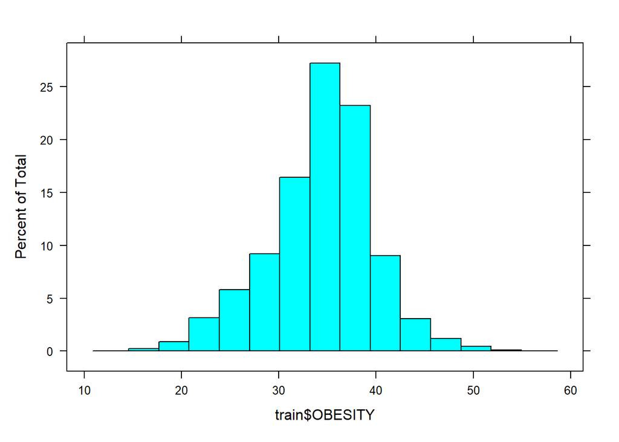

```r
# maybe skews left?
histogram(train$OBESITY)
```

## Obesity vs Grocery Stores per square mile

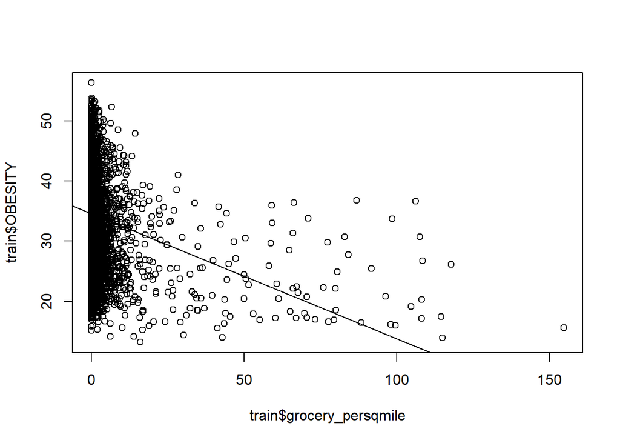

```r
plot(train$grocery_persqmile, train$OBESITY)
abline(lm(train$OBESITY~train$grocery_persqmile))
```

# Variable Selection - Two Methods

```r
fit.full <- lm(OBESITY ~ ., data=train)
stepAIC(fit.full, direction = "backward")
```

```
## Start:  AIC=37705.43
## OBESITY ~ aland10 + grocery_count + grocery_per1k + grocery_persqmile +
##     DEPRESSION + CANCER + CHOLSCREEN + CHD + white + black +
##     alaskan_native + asian + pacific_islan + other + mean_income +
##     X25.34_HS + X25.34_gtbach + X35.44_HS + X35.44_gtbach + X45.64_HS +
##     X45.64_gtbach + gt65_HS + gt65_gtbach
##
##                     Df Sum of Sq    RSS   AIC
## - white              1         0 154427 37703
## - DEPRESSION         1         3 154430 37704
## <none>                           154427 37705
## - grocery_per1k      1        21 154448 37706
## - alaskan_native     1        93 154520 37714
## - X25.34_HS          1       136 154563 37718
## - gt65_HS            1       179 154606 37723
## - mean_income        1       208 154636 37727
## - pacific_islan      1       244 154671 37730
## - other              1       251 154679 37731
## - X45.64_HS          1       257 154685 37732
## - X35.44_HS          1       258 154685 37732
## - X25.34_gtbach      1       270 154697 37733
## - CHOLSCREEN         1       336 154763 37741
## - grocery_count      1       454 154882 37754
## - X35.44_gtbach      1       513 154940 37760
## - aland10            1       646 155073 37775
## - grocery_persqmile  1      1958 156386 37919
## - X45.64_gtbach      1      2200 156628 37946
## - black              1      4348 158776 38179
## - gt65_gtbach        1      4444 158871 38189
## - asian              1      8373 162801 38608
## - CANCER             1     23126 177554 40093
## - CHD                1     49834 204262 42492
##
## Step:  AIC=37703.44
## OBESITY ~ aland10 + grocery_count + grocery_per1k + grocery_persqmile +
##     DEPRESSION + CANCER + CHOLSCREEN + CHD + black + alaskan_native +
##     asian + pacific_islan + other + mean_income + X25.34_HS +
##     X25.34_gtbach + X35.44_HS + X35.44_gtbach + X45.64_HS + X45.64_gtbach +
##     gt65_HS + gt65_gtbach
##
```

[output cut: 40 more lines]

```
## - X45.64_HS          1       259 154689 37728
## - X35.44_HS          1       260 154690 37729
## - other              1       264 154694 37729
## - X25.34_gtbach      1       272 154702 37730
## - CHOLSCREEN         1       335 154765 37737
## - X35.44_gtbach      1       514 154944 37757
## - grocery_count      1       662 155092 37773
## - aland10            1       663 155093 37773
## - grocery_persqmile  1      2200 156630 37942
## - X45.64_gtbach      1      2218 156648 37944
## - gt65_gtbach        1      4450 158880 38186
## - black              1      4456 158886 38187
## - asian              1      8587 163017 38626
## - CANCER             1     23972 178402 40170
## - CHD                1     55962 210392 42994
```

```
##
## Call:
## lm(formula = OBESITY ~ aland10 + grocery_count + grocery_per1k +
##     grocery_persqmile + CANCER + CHOLSCREEN + CHD + black + alaskan_native +
##     asian + pacific_islan + other + mean_income + X25.34_HS +
##     X25.34_gtbach + X35.44_HS + X35.44_gtbach + X45.64_HS + X45.64_gtbach +
##     gt65_HS + gt65_gtbach, data = train)
##
## Coefficients:
##       (Intercept)            aland10      grocery_count      grocery_per1k
##         2.589e+01         -7.360e-04         -4.357e-02         -4.676e-02
## grocery_persqmile             CANCER         CHOLSCREEN                CHD
##        -8.550e-02         -1.908e+00          8.452e-02          2.075e+00
##             black     alaskan_native              asian      pacific_islan
##         1.698e-04         -2.052e-04         -4.115e-04         -8.604e-04
##             other        mean_income          X25.34_HS      X25.34_gtbach
##        -7.616e-05         -5.601e-06          8.833e-03         -8.670e-03
##         X35.44_HS      X35.44_gtbach          X45.64_HS      X45.64_gtbach
##         1.245e-02         -1.269e-02          1.759e-02         -4.062e-02
##           gt65_HS        gt65_gtbach
##         1.072e-02         -4.848e-02
```

```r
# Backward step selection removes:
#   white, DEPRESSION
```

```r
# Using results from backward step to fit OLS model
data.step <- train[-c(6,10)]
lm.fitstep <- lm(OBESITY ~ ., data = data.step)
summary(lm.fitstep)
```

```
##
## Call:
## lm(formula = OBESITY ~ ., data = data.step)
##
## Residuals:
##      Min       1Q   Median       3Q      Max
## -19.5853  -1.8447   0.1737   1.9512  17.7564
##
## Coefficients:
##                     Estimate Std. Error t value Pr(>|t|)
## (Intercept)        2.589e+01  1.142e+00  22.671  < 2e-16 ***
## aland10           -7.360e-04  8.590e-05  -8.568  < 2e-16 ***
## grocery_count     -4.357e-02  5.090e-03  -8.560  < 2e-16 ***
## grocery_per1k     -4.676e-02  3.011e-02  -1.553 0.120446
## grocery_persqmile -8.550e-02  5.478e-03 -15.608  < 2e-16 ***
## CANCER            -1.908e+00  3.703e-02 -51.521  < 2e-16 ***
## CHOLSCREEN         8.452e-02  1.388e-02   6.089 1.16e-09 ***
## CHD                2.075e+00  2.637e-02  78.719  < 2e-16 ***
## black              1.698e-04  7.643e-06  22.212  < 2e-16 ***
## alaskan_native    -2.052e-04  6.311e-05  -3.252 0.001148 **
## asian             -4.115e-04  1.334e-05 -30.835  < 2e-16 ***
## pacific_islan     -8.604e-04  1.656e-04  -5.197 2.05e-07 ***
## other             -7.616e-05  1.409e-05  -5.406 6.53e-08 ***
## mean_income       -5.601e-06  1.157e-06  -4.841 1.31e-06 ***
## X25.34_HS          8.833e-03  2.273e-03   3.887 0.000102 ***
## X25.34_gtbach     -8.670e-03  1.579e-03  -5.490 4.07e-08 ***
## X35.44_HS          1.245e-02  2.320e-03   5.368 8.04e-08 ***
## X35.44_gtbach     -1.269e-02  1.682e-03  -7.541 4.90e-14 ***
## X45.64_HS          1.759e-02  3.283e-03   5.357 8.57e-08 ***
## X45.64_gtbach     -4.062e-02  2.592e-03 -15.672  < 2e-16 ***
## gt65_HS            1.072e-02  2.397e-03   4.474 7.73e-06 ***
## gt65_gtbach       -4.848e-02  2.184e-03 -22.198  < 2e-16 ***
## ---
## Signif. codes:  0 '***' 0.001 '**' 0.01 '*' 0.05 '.' 0.1 ' ' 1
##
## Residual standard error: 3.005 on 17100 degrees of freedom
## Multiple R-squared:  0.6911, Adjusted R-squared:  0.6907
## F-statistic:  1822 on 21 and 17100 DF,  p-value: < 2.2e-16
```

```r
# Based on F-value
dropterm(fit.full, test = "F")
```

|  | Df | Sum of Sq | RSS | AIC | F Value | Pr(F) |
| --- | --- | --- | --- | --- | --- | --- |
|  | NA | NA | 154427.4 | 37705.43 | NA | NA |
| aland10 | 1 | 6.456483e+02 | 155073.0 | 37774.87 | 7.148536e+01 | 3.015556e-17 |
| grocery_count | 1 | 4.543430e+02 | 154881.7 | 37753.74 | 5.030428e+01 | 1.368140e-12 |
| grocery_per1k | 1 | 2.067845e+01 | 154448.0 | 37705.73 | 2.289492e+00 | 1.302711e-01 |
| grocery_persqmile | 1 | 1.958314e+03 | 156385.7 | 37919.20 | 2.168221e+02 | 8.878806e-49 |
| DEPRESSION | 1 | 2.679679e+00 | 154430.0 | 37703.73 | 2.966906e-01 | 5.859717e-01 |
| CANCER | 1 | 2.312621e+04 | 177553.6 | 40092.78 | 2.560504e+03 | 0.000000e+00 |
| CHOLSCREEN | 1 | 3.359487e+02 | 154763.3 | 37740.64 | 3.719582e+01 | 1.091401e-09 |
| CHD | 1 | 4.983422e+04 | 204261.6 | 42492.08 | 5.517581e+03 | 0.000000e+00 |
| white | 1 | 4.685662e-02 | 154427.4 | 37703.44 | 5.187905e-03 | 9.425812e-01 |

[output cut: 14 more lines]

```r
fit1 <- update(fit.full, ~ . - white)
dropterm(fit1, sorted = TRUE, test = "F")
```

|  | Df | Sum of Sq | RSS | AIC | F Value | Pr(F) |
| --- | --- | --- | --- | --- | --- | --- |
| DEPRESSION | 1 | 2.634805 | 154430.0 | 37701.73 | 0.2917392 | 5.891152e-01 |
|  | NA | NA | 154427.4 | 37703.44 | NA | NA |
| grocery_per1k | 1 | 20.738326 | 154448.1 | 37703.74 | 2.2962547 | 1.297049e-01 |
| alaskan_native | 1 | 94.517182 | 154521.9 | 37711.92 | 10.4654310 | 1.218603e-03 |
| X25.34_HS | 1 | 135.707135 | 154563.1 | 37716.48 | 15.0261955 | 1.064253e-04 |
| gt65_HS | 1 | 178.718040 | 154606.1 | 37721.24 | 19.7885851 | 8.704340e-06 |
| mean_income | 1 | 208.225510 | 154635.6 | 37724.51 | 23.0558048 | 1.586985e-06 |
| pacific_islan | 1 | 244.305520 | 154671.7 | 37728.51 | 27.0507699 | 2.004668e-07 |
| other | 1 | 251.642906 | 154679.0 | 37729.32 | 27.8632033 | 1.317930e-07 |
| X45.64_HS | 1 | 257.501949 | 154684.9 | 37729.97 | 28.5119468 | 9.431176e-08 |

[output cut: 13 more lines]

```r
fit2 <- update(fit1, ~ . - DEPRESSION)
dropterm(fit2, sorted = TRUE, test = "F")
```

|  | Df | Sum of Sq | RSS | AIC | F Value | Pr(F) |
| --- | --- | --- | --- | --- | --- | --- |
|  | NA | NA | 154430.0 | 37701.73 | NA | NA |
| grocery_per1k | 1 | 21.78058 | 154451.8 | 37702.15 | 2.411758 | 1.204456e-01 |
| alaskan_native | 1 | 95.50615 | 154525.5 | 37710.32 | 10.575373 | 1.148262e-03 |
| X25.34_HS | 1 | 136.43759 | 154566.5 | 37714.85 | 15.107701 | 1.019315e-04 |
| gt65_HS | 1 | 180.75899 | 154610.8 | 37719.76 | 20.015399 | 7.731635e-06 |
| mean_income | 1 | 211.60683 | 154641.6 | 37723.18 | 23.431173 | 1.305939e-06 |
| pacific_islan | 1 | 243.90657 | 154673.9 | 37726.75 | 27.007714 | 2.049747e-07 |
| X45.64_HS | 1 | 259.16685 | 154689.2 | 37728.44 | 28.697482 | 8.570830e-08 |
| X35.44_HS | 1 | 260.27722 | 154690.3 | 37728.57 | 28.820432 | 8.044482e-08 |
| other | 1 | 263.94531 | 154694.0 | 37728.97 | 29.226600 | 6.525232e-08 |

[output cut: 12 more lines]

```r
# grocery_per_1k not signif
fit3 <- update(fit2, ~ . - grocery_per1k)
dropterm(fit3, sorted = TRUE, test = "F")
```

|  | Df | Sum of Sq | RSS | AIC | F Value | Pr(F) |
| --- | --- | --- | --- | --- | --- | --- |
|  | NA | NA | 154451.8 | 37702.15 | NA | NA |
| alaskan_native | 1 | 92.40088 | 154544.2 | 37710.39 | 10.23068 | 1.383753e-03 |
| X25.34_HS | 1 | 138.12128 | 154589.9 | 37715.45 | 15.29287 | 9.241874e-05 |
| gt65_HS | 1 | 180.62632 | 154632.4 | 37720.16 | 19.99906 | 7.797910e-06 |
| mean_income | 1 | 206.72055 | 154658.5 | 37723.05 | 22.88823 | 1.731331e-06 |
| pacific_islan | 1 | 245.92281 | 154697.7 | 37727.39 | 27.22873 | 1.828642e-07 |
| other | 1 | 255.54266 | 154707.4 | 37728.45 | 28.29384 | 1.055387e-07 |
| X45.64_HS | 1 | 259.86760 | 154711.7 | 37728.93 | 28.77270 | 8.244856e-08 |
| X35.44_HS | 1 | 263.45677 | 154715.3 | 37729.33 | 29.17010 | 6.717988e-08 |
| X25.34_gtbach | 1 | 274.91980 | 154726.7 | 37730.60 | 30.43929 | 3.494788e-08 |

[output cut: 11 more lines]

```r
summary(fit3)
```

```
##
## Call:
## lm(formula = OBESITY ~ aland10 + grocery_count + grocery_persqmile +
##     CANCER + CHOLSCREEN + CHD + black + alaskan_native + asian +
##     pacific_islan + other + mean_income + X25.34_HS + X25.34_gtbach +
##     X35.44_HS + X35.44_gtbach + X45.64_HS + X45.64_gtbach + gt65_HS +
##     gt65_gtbach, data = train)
##
## Residuals:
##      Min       1Q   Median       3Q      Max
## -19.5574  -1.8459   0.1776   1.9475  17.8060
##
## Coefficients:
##                     Estimate Std. Error t value Pr(>|t|)
## (Intercept)        2.592e+01  1.142e+00  22.694  < 2e-16 ***
## aland10           -7.427e-04  8.579e-05  -8.658  < 2e-16 ***
## grocery_count     -4.449e-02  5.056e-03  -8.798  < 2e-16 ***
## grocery_persqmile -8.671e-02  5.423e-03 -15.990  < 2e-16 ***
## CANCER            -1.907e+00  3.703e-02 -51.500  < 2e-16 ***
## CHOLSCREEN         8.401e-02  1.388e-02   6.053 1.45e-09 ***
## CHD                2.073e+00  2.632e-02  78.756  < 2e-16 ***
## black              1.706e-04  7.626e-06  22.370  < 2e-16 ***
## alaskan_native    -2.017e-04  6.308e-05  -3.199  0.00138 **
## asian             -4.104e-04  1.333e-05 -30.794  < 2e-16 ***
## pacific_islan     -8.639e-04  1.656e-04  -5.218 1.83e-07 ***
## other             -7.479e-05  1.406e-05  -5.319 1.06e-07 ***
## mean_income       -5.532e-06  1.156e-06  -4.784 1.73e-06 ***
## X25.34_HS          8.886e-03  2.272e-03   3.911 9.24e-05 ***
## X25.34_gtbach     -8.711e-03  1.579e-03  -5.517 3.49e-08 ***
## X35.44_HS          1.253e-02  2.320e-03   5.401 6.72e-08 ***
## X35.44_gtbach     -1.273e-02  1.682e-03  -7.569 3.97e-14 ***
## X45.64_HS          1.761e-02  3.283e-03   5.364 8.24e-08 ***
## X45.64_gtbach     -4.071e-02  2.591e-03 -15.710  < 2e-16 ***
## gt65_HS            1.072e-02  2.397e-03   4.472 7.80e-06 ***
## gt65_gtbach       -4.852e-02  2.184e-03 -22.214  < 2e-16 ***
## ---
## Signif. codes:  0 '***' 0.001 '**' 0.01 '*' 0.05 '.' 0.1 ' ' 1
##
## Residual standard error: 3.005 on 17101 degrees of freedom
## Multiple R-squared:  0.691,  Adjusted R-squared:  0.6907
## F-statistic:  1912 on 20 and 17101 DF,  p-value: < 2.2e-16
```

# Diagnostics on fit 3

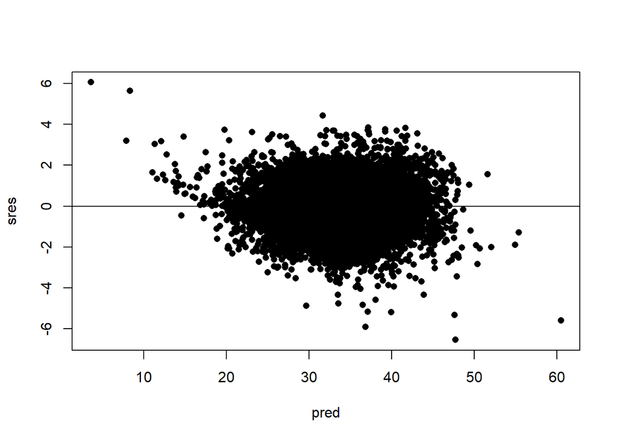

```r
pred = predict(fit3)
sres = stdres(fit3)
student = rstandard(fit3)
# Variance looks fairly stable
plot(pred, sres, pch=16); abline(h=0)
```

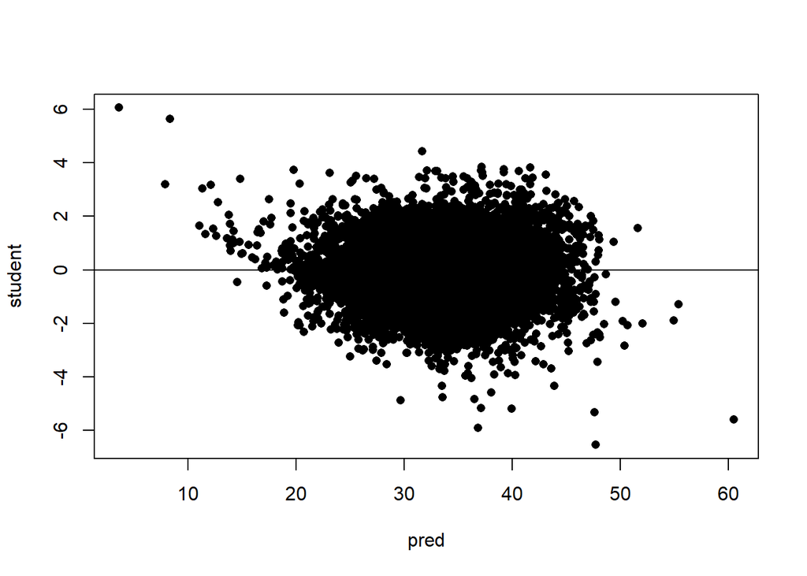

```r
plot(pred, student, pch=16); abline(h=0)
```

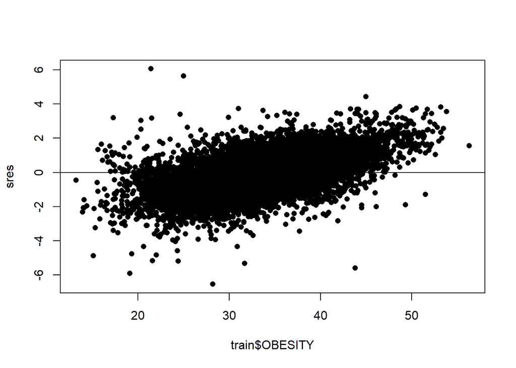

```r
# Variance increases with OBS but not wider/narrower spread
plot(train$OBESITY, sres, pch=16); abline(h=0)
```

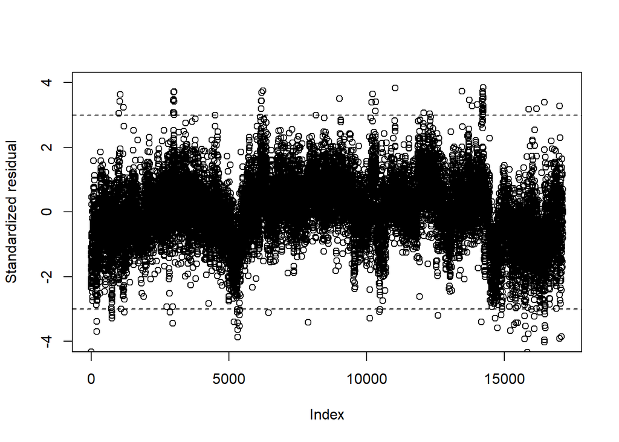

```r
# residual values increase with obesity, though variance doesn't change much
plot(sres, xlab = "Index", ylab = "Standardized residual", ylim = c(-4.0,4.0))
abline(h = -3.0, lty = 2)
abline(h = 3.0, lty = 2)
```

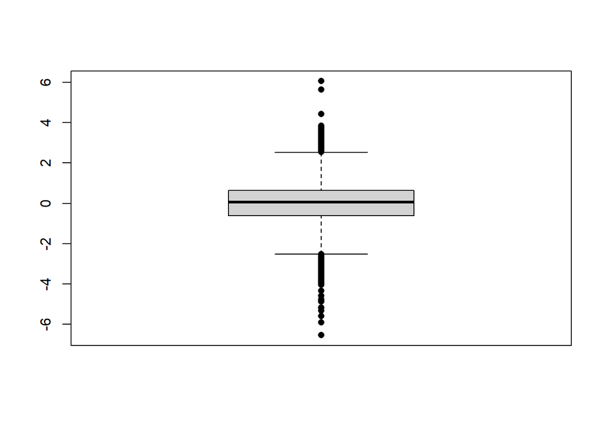

```r
boxplot(student, pch=16)
```

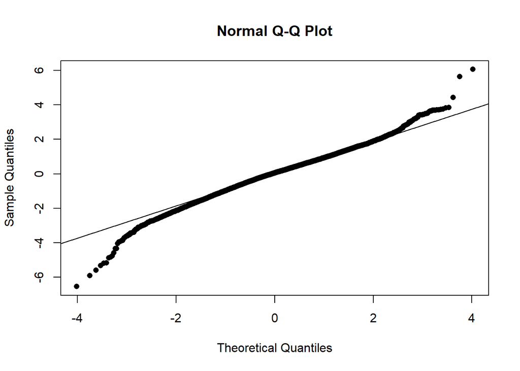

```r
# that's a lot of potential outliers? but maybe ok for 17k obs?

qqnorm(student, pch=16); qqline(student)
```

```r
# May not be normal at the ends, middle section looks good

# Shapiro-Wilk test for normality
# H0: model errors are normally distributed
# !must have 5000 or fewer observations! we have 17k in training
#shapiro.test(student)


# Breusch-Pagan - test for Homoskedasticity
# H0: residuals are homoskedastic
bptest(fit3, studentize=F)
```

```
##
##  Breusch-Pagan test
##
## data:  fit3
## BP = 840.07, df = 20, p-value < 2.2e-16
```

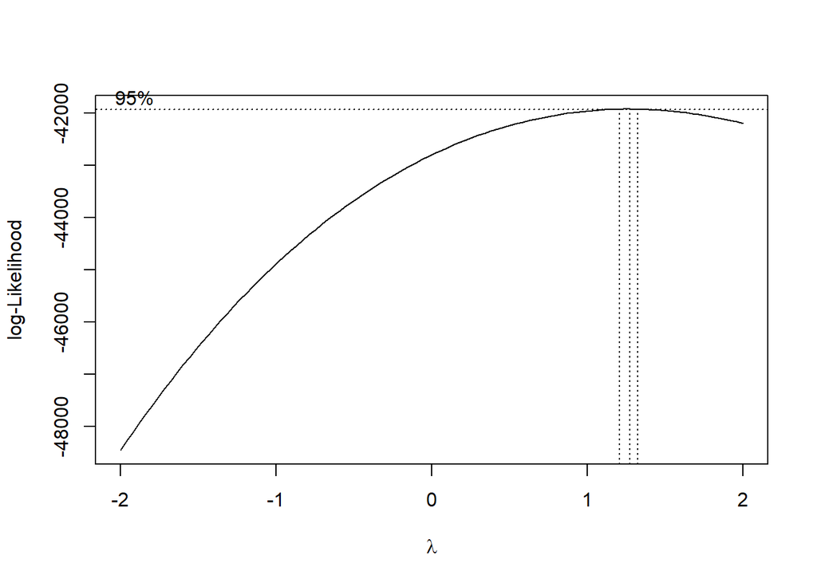

```r
# BP = 840.07, df = 20, p-value < 2.2e-16
# Reject H0 in favor of H1 - residuals are heteroskedastic

boxcox(fit3, lambda=seq(-2, 2, 0.1), plotit = T)
```

```r
# lambda ~ 1 => no transformation

# Multicollinearity?
multico = solve(cor(train[, -5]))
summary(multico)
```

```
##     aland10         grocery_count      grocery_per1k       grocery_persqmile
##  Min.   :-0.15116   Min.   :-1.76969   Min.   :-0.359921   Min.   :-1.373018
##  1st Qu.:-0.02881   1st Qu.:-0.26310   1st Qu.:-0.034050   1st Qu.:-0.042703
##  Median : 0.01922   Median :-0.02262   Median : 0.007021   Median : 0.006537
##  Mean   : 0.04871   Mean   :-0.07580   Mean   : 0.043069   Mean   : 0.041998
##  3rd Qu.: 0.03236   3rd Qu.: 0.06762   3rd Qu.: 0.064814   3rd Qu.: 0.046970
##  Max.   : 1.05093   Max.   : 4.32272   Max.   : 1.100502   Max.   : 1.701386
##    DEPRESSION           CANCER            CHOLSCREEN             CHD
##  Min.   :-0.81683   Min.   :-3.998919   Min.   :-2.489697   Min.   :-3.99892
##  1st Qu.:-0.02004   1st Qu.:-0.172333   1st Qu.:-0.092896   1st Qu.:-0.15872
##  Median : 0.05596   Median : 0.002078   Median : 0.013644   Median : 0.06038
##  Mean   : 0.08867   Mean   :-0.011539   Mean   : 0.004604   Mean   : 0.14291
##  3rd Qu.: 0.14708   3rd Qu.: 0.130012   3rd Qu.: 0.147553   3rd Qu.: 0.43957
##  Max.   : 1.49675   Max.   : 5.975409   Max.   : 2.884031   Max.   : 4.93210
##      white              black          alaskan_native          asian
##  Min.   :-1.76969   Min.   :-1.28967   Min.   :-0.281180   Min.   :-0.55944
##  1st Qu.:-0.10020   1st Qu.:-0.03393   1st Qu.:-0.049072   1st Qu.:-0.09819
##  Median :-0.02397   Median : 0.03631   Median :-0.002827   Median :-0.02564
##  Mean   : 0.04264   Mean   : 0.07592   Mean   : 0.031859   Mean   : 0.03062
##  3rd Qu.: 0.08933   3rd Qu.: 0.20468   3rd Qu.: 0.031240   3rd Qu.: 0.03869
##  Max.   : 2.35028   Max.   : 1.79860   Max.   : 1.128709   Max.   : 1.66179
##  pacific_islan          other           mean_income          X25.34_HS
##  Min.   :-0.42184   Min.   :-0.79234   Min.   :-0.969854   Min.   :-0.33554
##  1st Qu.:-0.03401   1st Qu.:-0.04685   1st Qu.:-0.105733   1st Qu.:-0.03421
##  Median :-0.01606   Median : 0.07831   Median : 0.002078   Median :-0.01208
##  Mean   : 0.03351   Mean   : 0.08588   Mean   : 0.075640   Mean   : 0.02849
##  3rd Qu.: 0.04656   3rd Qu.: 0.11643   3rd Qu.: 0.074695   3rd Qu.: 0.02515
##  Max.   : 1.17373   Max.   : 1.78298   Max.   : 2.949547   Max.   : 1.27845
##  X25.34_gtbach         X35.44_HS        X35.44_gtbach        X45.64_HS
##  Min.   :-0.559633   Min.   :-0.38228   Min.   :-0.72127   Min.   :-0.74926
##  1st Qu.:-0.128228   1st Qu.:-0.06835   1st Qu.:-0.10348   1st Qu.:-0.09906
##  Median :-0.002162   Median :-0.01173   Median :-0.02262   Median :-0.02267
##  Mean   : 0.029735   Mean   : 0.02499   Mean   : 0.01741   Mean   : 0.03375
##  3rd Qu.: 0.054688   3rd Qu.: 0.05754   3rd Qu.: 0.02362   3rd Qu.: 0.03953
##  Max.   : 2.089272   Max.   : 1.47299   Max.   : 2.43098   Max.   : 2.01249
##  X45.64_gtbach          gt65_HS           gt65_gtbach
##  Min.   :-1.063068   Min.   :-0.907109   Min.   :-1.06307
##  1st Qu.:-0.169230   1st Qu.:-0.053430   1st Qu.:-0.10132
##  Median :-0.031085   Median :-0.002981   Median :-0.01432
##  Mean   :-0.003589   Mean   : 0.041194   Mean   : 0.00278
##  3rd Qu.: 0.053225   3rd Qu.: 0.077797   3rd Qu.: 0.02808
##  Max.   : 3.647515   Max.   : 1.828711   Max.   : 2.33695
```

```r
# Now, no values above 10!
# Multicollinearity fixed by removing population variables
```

```r
# Using results from manual F-Test variable selection to fit OLS model
data.F <- train[-c(3,6,10)]
lm.fitF <- lm(OBESITY ~ ., data = data.F)
summary(lm.fitF)
```

```
##
## Call:
## lm(formula = OBESITY ~ ., data = data.F)
##
## Residuals:
##      Min       1Q   Median       3Q      Max
## -19.5574  -1.8459   0.1776   1.9475  17.8060
##
## Coefficients:
##                     Estimate Std. Error t value Pr(>|t|)
## (Intercept)        2.592e+01  1.142e+00  22.694  < 2e-16 ***
## aland10           -7.427e-04  8.579e-05  -8.658  < 2e-16 ***
## grocery_count     -4.449e-02  5.056e-03  -8.798  < 2e-16 ***
## grocery_persqmile -8.671e-02  5.423e-03 -15.990  < 2e-16 ***
## CANCER            -1.907e+00  3.703e-02 -51.500  < 2e-16 ***
## CHOLSCREEN         8.401e-02  1.388e-02   6.053 1.45e-09 ***
## CHD                2.073e+00  2.632e-02  78.756  < 2e-16 ***
## black              1.706e-04  7.626e-06  22.370  < 2e-16 ***
## alaskan_native    -2.017e-04  6.308e-05  -3.199  0.00138 **
## asian             -4.104e-04  1.333e-05 -30.794  < 2e-16 ***
## pacific_islan     -8.639e-04  1.656e-04  -5.218 1.83e-07 ***
## other             -7.479e-05  1.406e-05  -5.319 1.06e-07 ***
## mean_income       -5.532e-06  1.156e-06  -4.784 1.73e-06 ***
## X25.34_HS          8.886e-03  2.272e-03   3.911 9.24e-05 ***
## X25.34_gtbach     -8.711e-03  1.579e-03  -5.517 3.49e-08 ***
## X35.44_HS          1.253e-02  2.320e-03   5.401 6.72e-08 ***
## X35.44_gtbach     -1.273e-02  1.682e-03  -7.569 3.97e-14 ***
## X45.64_HS          1.761e-02  3.283e-03   5.364 8.24e-08 ***
## X45.64_gtbach     -4.071e-02  2.591e-03 -15.710  < 2e-16 ***
## gt65_HS            1.072e-02  2.397e-03   4.472 7.80e-06 ***
## gt65_gtbach       -4.852e-02  2.184e-03 -22.214  < 2e-16 ***
## ---
## Signif. codes:  0 '***' 0.001 '**' 0.01 '*' 0.05 '.' 0.1 ' ' 1
##
## Residual standard error: 3.005 on 17101 degrees of freedom
## Multiple R-squared:  0.691,  Adjusted R-squared:  0.6907
## F-statistic:  1912 on 20 and 17101 DF,  p-value: < 2.2e-16
```

# XGBoost

```r
# XGBoost is an ensemble method, similar to Random Forest
# Except not random, tree N+1 is based on the loss from tree N
# https://xgboost.readthedocs.io/en/latest/R-package/xgboostPresentation.html
# XGB Params: https://xgboost.readthedocs.io/en/latest/parameter.html?highlight=objective
xgbtrain = xgb.DMatrix(as.matrix(sapply(X_train, as.numeric)), label=y_train$OBESITY)
xgbvalid = xgb.DMatrix(as.matrix(sapply(X_valid, as.numeric)), label=y_valid$OBESITY)
watchlist <- list(train=xgbtrain, test=xgbvalid)

# max.depth = 4 and nrounds=10 yielded minimum test-rmse
xgb.fit <- xgb.train(data=xgbtrain, max.depth = 4, eta = 1, nthread = 2, nrounds = 10,
                   watchlist=watchlist, objective = "reg:squarederror")
# linear boosting - not as good
lin.fit <- xgb.train(data=xgbtrain, booster = "gblinear", nthread = 2, nrounds=10,
                 watchlist=watchlist, objective = "reg:squarederror")
summary(xgb.fit)
```

```
##                Length Class              Mode
## handle             1  xgb.Booster.handle externalptr
## raw            23283  -none-             raw
## niter              1  -none-             numeric
## evaluation_log     3  data.table         list
## call               8  -none-             call
## params             5  -none-             list
## callbacks          2  -none-             list
## feature_names     23  -none-             character
## nfeatures          1  -none-             numeric
```

```r
# Plot of variable importance
# Gain - is the improvement in accuracy brought by a feature to the branches it is on
# Cover - measures the relative quantity of observations concerned by a feature
# Frequency - is a simpler way to measure the Gain. It just counts the number of
#   times a feature is used in all generated trees
#   !You should not use it (unless you know why you want to use it)!
importance_matrix <- xgb.importance(model = xgb.fit)
print(importance_matrix)
```

```
##               Feature         Gain        Cover   Frequency
##  1:     X45.64_gtbach 0.4430384717 0.0675804127 0.061224490
##  2:       mean_income 0.1997192237 0.1498730422 0.108843537
##  3:               CHD 0.0948227668 0.1719267660 0.136054422
##  4:             black 0.0444389604 0.1138619861 0.081632653
##  5:            CANCER 0.0424096513 0.1094290474 0.095238095
##  6:             asian 0.0386745134 0.0782305625 0.054421769
##  7:        DEPRESSION 0.0330242819 0.0519118143 0.102040816
##  8: grocery_persqmile 0.0300632592 0.0131440428 0.047619048
##  9:       gt65_gtbach 0.0272524100 0.0133411596 0.040816327
## 10:        CHOLSCREEN 0.0197877196 0.0578223992 0.054421769
## 11:           aland10 0.0086544081 0.0475723236 0.081632653
## 12:             white 0.0079322873 0.0061821681 0.047619048
## 13:             other 0.0058725939 0.0584079092 0.040816327
## 14:         X45.64_HS 0.0019142159 0.0324760941 0.020408163
## 15:           gt65_HS 0.0012862149 0.0144201918 0.013605442
## 16:     X35.44_gtbach 0.0006004792 0.0133966443 0.006802721
## 17:     grocery_count 0.0005085427 0.0004234362 0.006802721
```

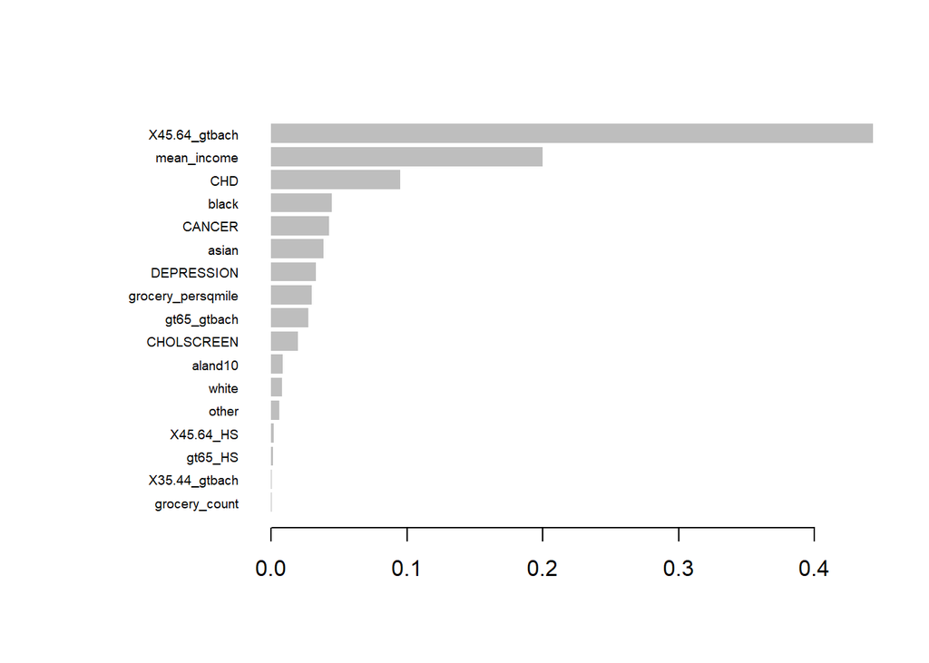

```r
xgb.plot.importance(importance_matrix = importance_matrix)
```

xgboost’s gain shows that percent of the population of age 45-65 with a bachelor’s degree or greater, mean income, percent of population with chronic heart disease, percent of population which is black and percent of population with cancer are the five most important variables in determining percent of population with obesity. Number of grocery stores per square mile is the eigth most important variable.

```r
# View model trees
# with depth=5 the tree ends up having 608 nodes/leaves
# Commented out since output isn't helpful - >600 lines describing the tree
#xgb.dump(xgb.fit, with_stats = TRUE)


# For example tree with depth = 2... plotting a 5 level tree is not helpful
# With this many variables, its still not visible
xgb.fit2 <- xgb.train(data=xgbtrain, max.depth = 4, eta = 1, nthread = 2, nrounds = 10,
                     watchlist=watchlist, objective = "reg:squarederror")
xgb.plot.tree(model = xgb.fit2, trees=0) # just from 0th root node
```

[interactive chart not shown]

# Compare Models - RMSE

```r
# Compare RMSE of linear and XGB Models
xgbtest = xgb.DMatrix(as.matrix(sapply(X_test, as.numeric)), label=y_test$OBESITY)

linpred <- predict.lm(fit3, test)
xgbpred <- predict(xgb.fit, xgbtest)

# RMSE of linear model on test set
sqrt(mean((test$OBESITY - linpred)^2))
```

```
## [1] 2.986013
```

```r
# RMSE of XGBoost model on test set
sqrt(mean((test$OBESITY - xgbpred)^2))
```

```
## [1] 3.034223
```

# Supervised Analysis Conclusion

When controlling for variables such as income, race, education and various illnesses, we have found a negative association between the number of grocery stores per square mile in a zip code area and percent of inhabitants who are obese. For every increase of one grocery store per square mile, obesity decreases by 0.0867%. We found some other interesting associations with obesity. As the percentage of inhabitants who are black increases, so does obesity. Obesity decreases with income and education.

Using xgboost to look at non-linear associations with obesity, we found that education (percent of inhabitants between 45 and 65 years of age with a bachelors or greater), mean income and being black are important variables in determining obesity. Number of grocery stores per square mile, to a lesser degree, is also important to explaining obesity.

With a RMSE of 2.986 our linear model, fit3, outperformed the XGBoost model, which had a RMSE of 3.034, on the test data.

# Grocery Store Data

Project Citation: Finlay, Jessica, Li, Mao, Esposito, Michael, Gomez-Lopez, Iris, Khan, Anam, Clarke, Philippa, and Chenoweth, Megan. National Neighborhood Data Archive (NaNDA): Grocery Stores by ZIP Code Tabulation Area, United States, 2003-2017. Ann Arbor, MI: Inter-university Consortium for Political and Social Research [distributor], 2020-10-01. https://doi.org/10.3886/E123042V1